# Applying CSIDE to Spatial Transcriptomics Data: Multiple regions in Visium with full mode RCTD

Dylan Cable

December 20th, 2021

```r
library(spacexr)
library(Matrix)
library(doParallel)
```

```r
library(ggplot2)
datadir <- system.file("extdata",'SpatialRNA/VisiumVignette',package = 'spacexr') # directory for sample Visium dataset
if(!dir.exists(datadir))
  dir.create(datadir)
savedir <- 'RCTD_results'
if(!dir.exists(savedir))
  dir.create(savedir)
```

```r
knitr::opts_chunk$set(
  collapse = TRUE,
  comment = "#>",
  cache = TRUE,
  out.width = "100%"
)
```

## Introduction

Cell type-Specific Inference of Differential Expression, or CSIDE, is part of the *spacexr* R package for learning cell type-specific differential expression from spatial transcriptomics data. In this Vignette, we will use CSIDE to test for differential expression across multiple regions in a toy hippocampus Visium dataset. First, we will first use RCTD to assign cell types to a hippocampus Visium dataset. We will define cell type profiles using an annotated single cell RNA-sequencing (scRNA-seq) hippocampus dataset. We will test for differential expression across three spatial regions.

## Data Preprocessing and running RCTD

First, we run RCTD on the data to annotated cell types. Please note that this follows exactly the content of the spatial transcriptomics RCTD vignette, except that we use RCTD on full mode. Since full mode can discover any number of cell types per pixel, it is a reasonable choice for technologies such as Visium that can have spatial resolution much larger than single cells. Please refer to the [spatial transcriptomics vignette](https://raw.githack.com/dmcable/spacexr/master/vignettes/spatial-transcriptomics.html) for more explanation on the RCTD algorithm.

```r
### Load in/preprocess your data, this might vary based on your file type
if(!file.exists(file.path(savedir,'myRCTD_visium_full.rds'))) {
  counts <- as.data.frame(readr::read_csv(file.path(datadir,"counts.csv"))) # load in counts matrix
  coords <- read.csv(file.path(datadir,"coords.csv"))
  rownames(counts) <- counts[,1]; counts[,1] <- NULL # Move first column to rownames
  rownames(coords) <- coords[,1]; coords[,1] <- NULL # Move first column to rownames
  nUMI <- colSums(counts) # In this case, total counts per pixel is nUMI
  puck <- SpatialRNA(coords, counts, nUMI)
  barcodes <- colnames(puck@counts) # pixels to be used (a list of barcode names).
  plot_puck_continuous(puck, barcodes, puck@nUMI, ylimit = c(0,round(quantile(puck@nUMI,0.9))),
                       title ='plot of nUMI')
  refdir <- system.file("extdata",'Reference/Visium_Ref',package = 'spacexr') # directory for the reference
  counts <- read.csv(file.path(refdir,"counts.csv")) # load in cell types
  rownames(counts) <- counts[,1]; counts[,1] <- NULL # Move first column to rownames
  cell_types <- read.csv(file.path(refdir,"cell_types.csv")) # load in cell types
  cell_types <- setNames(cell_types[[2]], cell_types[[1]])
  cell_types <- as.factor(cell_types) # convert to factor data type
  nUMI <- read.csv(file.path(refdir,"nUMI.csv")) # load in cell types
  nUMI <- setNames(nUMI[[2]], nUMI[[1]])
  reference <- Reference(counts, cell_types, nUMI)
  myRCTD <- create.RCTD(puck, reference, max_cores = 2)
  myRCTD <- run.RCTD(myRCTD, doublet_mode = 'full')
  saveRDS(myRCTD,file.path(savedir,'myRCTD_visium_full.rds'))
}
```

## Exploring the full mode results

The results of RCTD full mode are stored in `@results$weights`. We next normalize the weights using `normalize_weights` so that they sum to one. Each entry represents the estimated proportion of each cell type on each pixel.

```r
myRCTD <- readRDS(file.path(savedir,'myRCTD_visium_full.rds'))
barcodes <- colnames(myRCTD@spatialRNA@counts)
weights <- myRCTD@results$weights
norm_weights <- normalize_weights(weights)
cell_types <- c('Neurogenesis','Astrocyte')
print(head(norm_weights[,cell_types])) # observe weight values
```

```
#> 6 x 2 Matrix of class "dgeMatrix"
#>                    Neurogenesis  Astrocyte
#> AAAGGGATGTAGCAAG-1    0.2973533 0.05574455
#> AAAGGGCAGCTTGAAT-1    0.1662856 0.01127636
#> AACAACTGGTAGTTGC-1    0.1972219 0.06214291
#> AACCCAGAGACGGAGA-1    0.3324192 0.05533508
#> AACCGAGCTTGGTCAT-1    0.2902799 0.06701348
#> AACGATAGAAGGGCCG-1    0.4253288 0.04751156
```

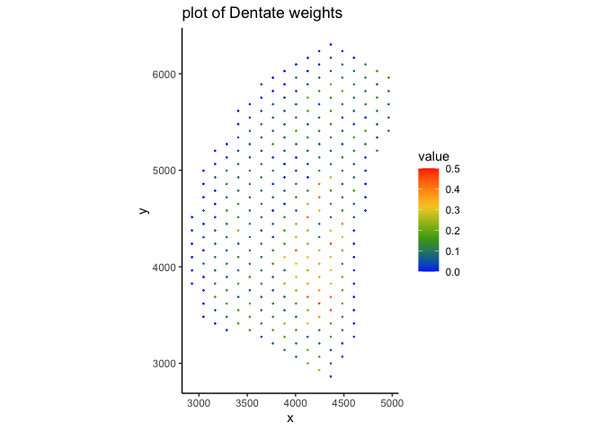

```r
plot_puck_continuous(myRCTD@spatialRNA, barcodes, norm_weights[,'Denate'], ylimit = c(0,0.5),
                     title ='plot of Dentate weights') # plot Dentate weights
```

## Choose regions

Now that we have successfully run RCTD, we can create a set of regions used for predicting differential expression in CSIDE. In this case, we will create three lists representing membership in the left, middle, or right regions. We construct `region_list` which is a list of these three lists.

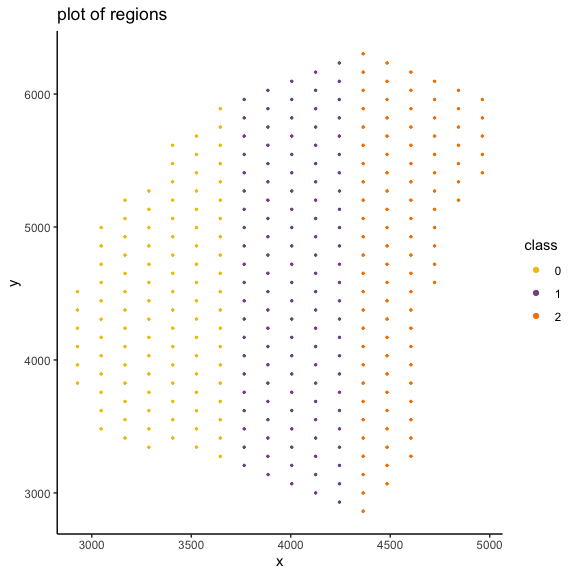

```r
### Create SpatialRNA object
region_left <- barcodes[which(myRCTD@spatialRNA@coords$x < quantile(myRCTD@spatialRNA@coords$x, 1/3))]
region_right <- barcodes[which(myRCTD@spatialRNA@coords$x > quantile(myRCTD@spatialRNA@coords$x, 2/3))]
region_middle <- setdiff(barcodes, union(region_left, region_right))
region_list <- list(region_left, region_right, region_middle)

# Differentially downregulate one gene
gene_list <- c('Fth1', 'Bsg')
myRCTD@originalSpatialRNA@counts <- myRCTD@spatialRNA@counts[gene_list,]
class_num <- rep(0, length(barcodes)); names(class_num) <- barcodes
class_num[region_middle] <- 1; class_num[region_right] <- 2
plot_class(myRCTD@spatialRNA, barcodes, factor(class_num),  title ='plot of regions') # plot regions
```

## Running CSIDE

After creating the list of regions, we are now ready to run CSIDE using the `run.CSIDE.regions` function. We will use two cores, and a false discovery rate of 0.25. Next, we will set a gene threshold (i.e. minimum gene expression) of 0.01, and we will set a cell_type_threshold (minimum instances per cell type) of 10.

**Warning**: On this toy dataset, we have made several choices of parameters that are not recommended for regular use. On real datasets, we recommend first consulting the CSIDE default parameters. This includes `gene_threshold` (default 5e-5), `cell_type_threshold` (default 125), `fdr` (default 0.01), and `weight_threshold` (default NULL). Please see `?run.CSIDE.regions` for more information on these parameters.

```r
#de
myRCTD@config$max_cores <- 2
myRCTD <- run.CSIDE.regions(myRCTD, region_list,cell_types = cell_types, gene_threshold = .01, cell_type_threshold = 10, fdr = 0.25, doublet_mode = F, weight_threshold = 0.1)
```

```
#> Warning in run.CSIDE.general(myRCTD, X1, X2, barcodes, cell_types,
#> cell_type_threshold = cell_type_threshold, : run.CSIDE.general: some parameters
#> are set to the CSIDE vignette values, which are intended for testing but
#> not proper execution. For more accurate results, consider using the default
#> parameters to this function.
#> run.CSIDE.general: running CSIDE with cell types Neurogenesis, Astrocyte
#> run.CSIDE.general: configure params_to_test = 1, 2, 3,
#> filter_genes: filtering genes based on threshold = 0.01
```

```r
saveRDS(myRCTD,file.path(savedir,'myRCTDde_visium_regions.rds'))
```

Equivalently to using the `run.CSIDE.regions` function, those who want to have more precise control can build the design matrix directly. In this case, we use the `build.designmatrix.regions` function, which constructs the design matrix given a list of regions. After constructing the design matrix, one can use the `run.CSIDE` function (with test_mode = ‘categorical’) to run CSIDE with this general design matrix.

```r
X <- build.designmatrix.regions(myRCTD,region_list)
print(head(X))
```

```
#>                    [,1] [,2] [,3]
#> AACCCAGAGACGGAGA-1    1    0    0
#> AACGATAGAAGGGCCG-1    1    0    0
#> AACTGGGTCCCGACGT-1    1    0    0
#> AAGTAGAAGACCGGGT-1    1    0    0
#> AATGGTTCTCACAAGC-1    1    0    0
#> ACACCCGAGAAATCCG-1    1    0    0
```

```r
barcodes <- rownames(X)
myRCTD_identical <- run.CSIDE(myRCTD, X, barcodes, cell_types, test_mode = 'categorical', gene_threshold = .01, doublet_mode = F, cell_type_threshold = 10, fdr = 0.25, weight_threshold = 0.1)
```

## CSIDE results

After running CSIDE, it is time to examine CSIDE results. We will focus on cell type Neurogenesis. Furthermore, we will examine the original Fth1 gene.

```r
#print results for cell type 'Dentate'
cell_type <- 'Neurogenesis'
gene <- 'Fth1'
print(paste("following results hold for", gene))
```

```
#> [1] "following results hold for Fth1"
```

```r
print("check for covergence of each cell type")
```

```
#> [1] "check for covergence of each cell type"
```

```r
print(myRCTD@de_results$gene_fits$con_mat[gene, ]) # did not converge (dataset was too small)
```

```
#> Neurogenesis    Astrocyte
#>         TRUE        FALSE
```

```r
print('estimated expression for Neurogenesis in each region')
```

```
#> [1] "estimated expression for Neurogenesis in each region"
```

```r
cell_type_ind <- which(cell_type == cell_types)
print(myRCTD@de_results$gene_fits$all_vals[gene, , cell_type_ind])
```

```
#> [1] -3.322362 -3.116246 -3.369826
```

Unfortunately, this toy dataset did not yield any significant genes, so we will examine `myRCTD@de_results$all_gene_list` (all genes) and `myRCTD@de_results$sig_gene_list` (significant genes). `sig_gene_list` is a list, for each cell type, of dataframes that contain the hypothesis testing results for significant genes. In particular, notice the following columns:

- `mean_i`: the estimated log gene expression in region i.
- `sd_i`: the standard error of this log gene expression estimate in region i.
- `sd_lfc`: the standard deviation of `mean_i`, across i.
- `log_fc_best`: the log-fold-change of the most differentially-expressed significant pair of regions.
- `sd_best`: the standard error of the log-fold-change estimate of this pair
- `p_val_best`: the p value of the differential expression for this pair.
- `paramindex1_best`: the parameter index for the first region in the most DE pair.
- `paramindex2_best`: the parameter index for the second region in the most DE pair.

```r
sig_gene_list <- myRCTD@de_results$sig_gene_list
print(sig_gene_list$Neurogenesis)
```

```
#>  [1] sd_lfc           paramindex1_best paramindex2_best sd_best
#>  [5] p_val_best       log_fc_best      mean_1           mean_2
#>  [9] mean_3           sd_1             sd_2             sd_3
#> <0 rows> (or 0-length row.names)
```

```r
all_gene_list <- myRCTD@de_results$all_gene_list
print(all_gene_list$Neurogenesis)
```

```
#>         sd_lfc paramindex1_best paramindex2_best    sd_best   p_val_best
#> Fth1 0.1348083                2                3 0.03645868 1.055599e-11
#>      log_fc_best    mean_1    mean_2    mean_3       sd_1       sd_2       sd_3
#> Fth1   0.2535803 -3.322362 -3.116246 -3.369826 0.04623312 0.02245107 0.02872603
```

Finally, we will plot CSIDE results in the `savedir` directory!

The following plot shows a spatial visualization of the Fth1 gene.

The function `make_all_de_plots` will automatically generate several types of plots displaying the CSIDE results across all genes and cell types. Typically, one would want to plot one or multiple significant genes. For this toy dataset, no genes were significant.

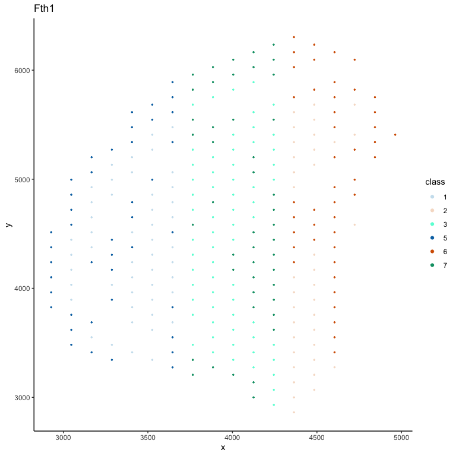

```r
myRCTD <- readRDS(file.path(savedir,'myRCTDde_visium_regions.rds'))
plot_gene_regions(myRCTD, cell_type, gene, pixel_weight_thresh = 0.15, expr_thresh = 8)
```

```r
make_all_de_plots(myRCTD, savedir)
```